# Climate change, tree loss, and food security

Author

Fidel Ovalle, Sam Reffuge, and Zoey Ziegler

Introduction

Over the past few decades, climate change and the degradation of the environment have become some of the most important challenges. Increasing CO2 emissions, rising temperatures, tree loss, and food insecurity are interconnected issues that affect countries around the world. This project looks into certain stigmas related to these topics, whether that being that higher CO2 emissions are connected to increased temperature, how tree loss affects the CO2 emissions greatly, and how these environmental issues relate to food production and food insecurity across the world. Understanding these relationships is important because environmental changes can directly impact ecosystems, agriculture, economy, and the health of humans. The goal of this report is to demonstrate some of the connections between climate change, tree loss, and food security. Our focus is agriculture; we examine total carbon emissions from agriculture, food consumption emissions, and food production measures. We will first visualize climate change trends and how they relate to other environmental changes like tree loss. Then we will add in human impacts like food consumption emissions and population trends. Finally, we tie all issues together by looking at connections between food production, environmental change, and undernourishment. There is a delicate balance between environmental and human needs. Examining the connections between the two, through agriculture, is vital if we are to create a sustainable, thriving world.

Figure 1

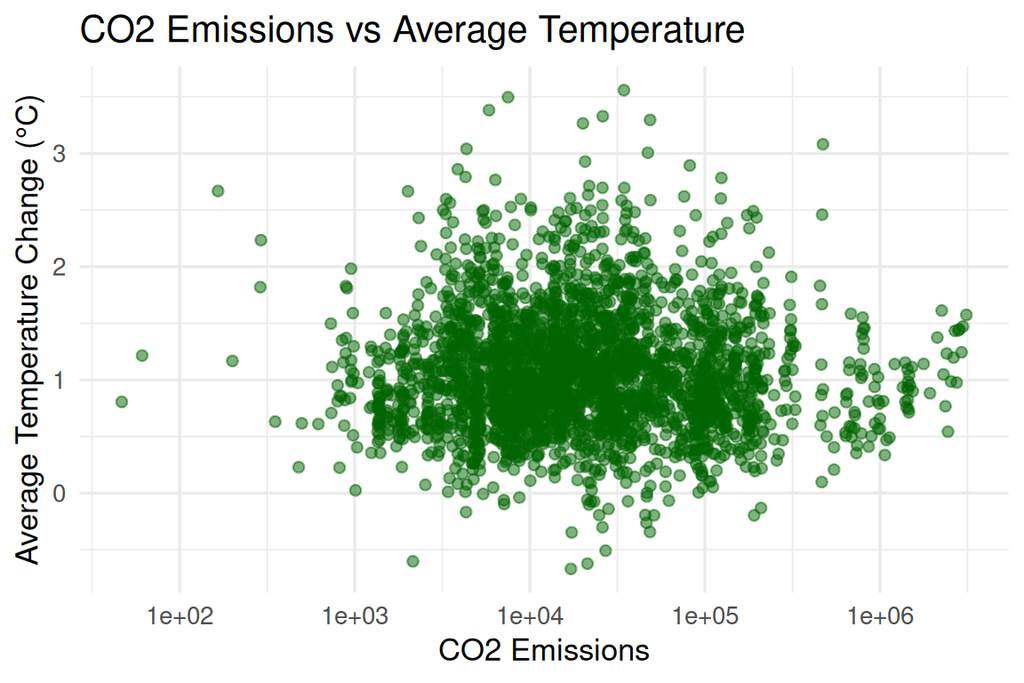

This graph displays the relationship between agricultural CO2 emissions and average temperature change across countries from 2001 to 2020. Each point represents a country-year observation, with CO2 emissions shown on a logarithmic scale to better display the large variation in emission levels between countries. Most observations are condensed between moderate CO2 emission values and temperature changes between approximately 0.5°C and 1.5°C. The graph suggests that countries with higher CO2 emissions often experience positive temperature changes, although the relationship does not appear perfectly linear.

Figure 2

Top 10 Countries by Average Tree Loss and Temperature Change

| country | avg_tree_loss | avg_temp_change |
| --- | --- | --- |
| RUS | 3684896.2 | 1.7680583 |
| BRA | 3047407.9 | 1.0789792 |
| CAN | 2754906.3 | 1.3224875 |
| IDN | 1324997.5 | 0.7313292 |
| CHN | 536700.7 | 1.1680292 |
| MYS | 391072.4 | 1.0758667 |
| AUS | 384097.5 | 0.9207750 |
| PRY | 294750.8 | 0.7496542 |
| ARG | 286665.0 | 0.6029208 |
| SWE | 256732.7 | 1.5642208 |

This table displays the top 10 countries with the highest average tree loss along with their corresponding average temperature change values from 2001 to 2020. Russia, Brazil, and Canada show the highest levels of average tree loss in the dataset, with all three countries also experiencing positive average temperature changes over the same period. The table highlights that countries with substantial forest loss are located across different regions of the world, suggesting that tree loss is a widespread global issue rather than one limited to a single geographic area.

The results also suggest that many countries with high levels of tree loss experienced noticeable increases in average temperature change. For example, Russia and Sweden both show relatively high temperature increases alongside significant forest loss values. While the table does not prove a direct causal relationship, it demonstrates a potential association between deforestation and rising temperatures. Overall, the table emphasizes the importance of forests in global climate systems and highlights how environmental changes may be connected across countries over time.

Figure 3

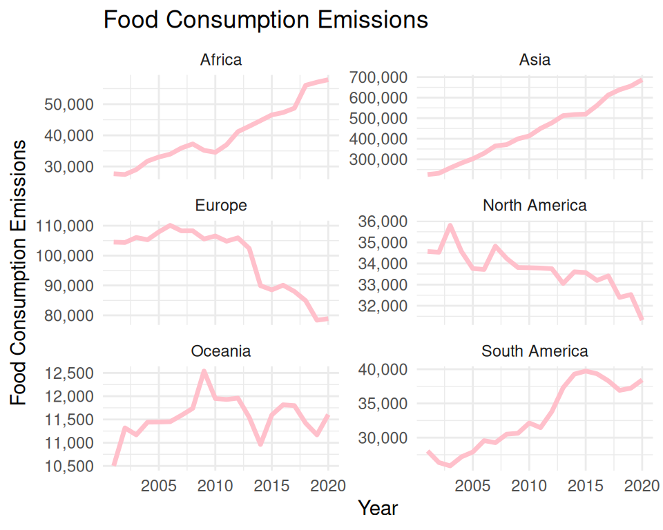

Figure 4

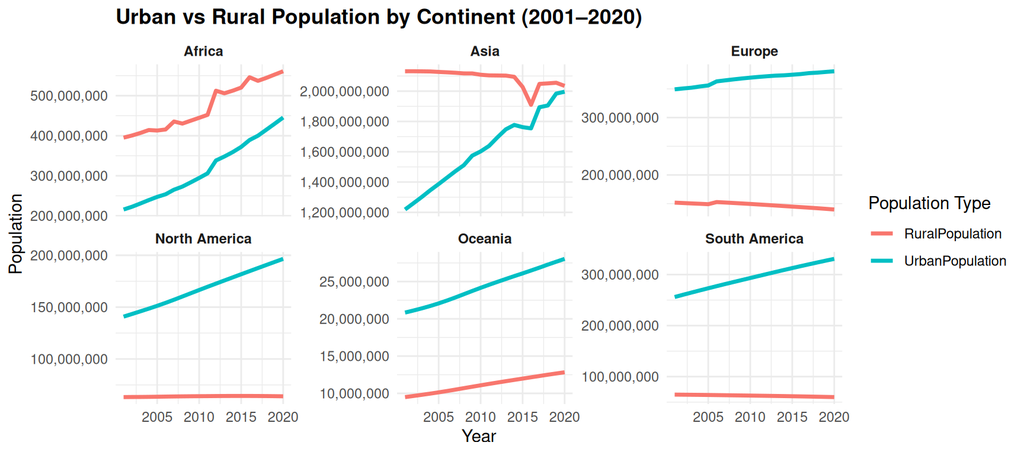